# Capstone Final Project Code

Importing Libraries

```python
import numpy as np
import pandas as pd
import matplotlib.pyplot as plt
import seaborn as sns
```

Loading the data from the csv file

```python
fake = pd.read_csv('Fake.csv')
true = pd.read_csv('True.csv')
```

```python
f_shape = fake.shape
t_shape = true.shape
print("Fake shape:", f_shape)
print("True shape:", t_shape)
```

```
Fake shape: (16920, 4)
True shape: (21417, 4)
```

# Preparing the data

```python
fake['target'] = 0
true['target'] = 1
```

```python
fake.head()
```

|  | title | text | subject | date | target |
| --- | --- | --- | --- | --- | --- |
| 0 | Donald Trump Sends Out Embarrassing New Year’... | Donald Trump just couldn t wish all Americans ... | News | 31-Dec-17 | 0 |
| 1 | Drunk Bragging Trump Staffer Started Russian ... | House Intelligence Committee Chairman Devin Nu... | News | 31-Dec-17 | 0 |
| 2 | Sheriff David Clarke Becomes An Internet Joke... | On Friday, it was revealed that former Milwauk... | News | 30-Dec-17 | 0 |
| 3 | Trump Is So Obsessed He Even Has Obama’s Name... | On Christmas day, Donald Trump announced that ... | News | 29-Dec-17 | 0 |
| 4 | Pope Francis Just Called Out Donald Trump Dur... | Pope Francis used his annual Christmas Day mes... | News | 25-Dec-17 | 0 |

```python
true.head()
```

|  | title | text | subject | date | target |
| --- | --- | --- | --- | --- | --- |
| 0 | As U.S. budget fight looms, Republicans flip t... | WASHINGTON (Reuters) - The head of a conservat... | politicsNews | December 31, 2017 | 1 |
| 1 | U.S. military to accept transgender recruits o... | WASHINGTON (Reuters) - Transgender people will... | politicsNews | December 29, 2017 | 1 |
| 2 | Senior U.S. Republican senator: 'Let Mr. Muell... | WASHINGTON (Reuters) - The special counsel inv... | politicsNews | December 31, 2017 | 1 |
| 3 | FBI Russia probe helped by Australian diplomat... | WASHINGTON (Reuters) - Trump campaign adviser ... | politicsNews | December 30, 2017 | 1 |
| 4 | Trump wants Postal Service to charge 'much mor... | SEATTLE/WASHINGTON (Reuters) - President Donal... | politicsNews | December 29, 2017 | 1 |

Convert text column into string datatype

```python
fake['text'] = fake['text'].astype(str)
true['text'] = true['text'].astype(str)
```

Concatenating the dataframes

```python
data = pd.concat([fake, true])
data.shape
data
```

|  | title | text | subject | date | target |
| --- | --- | --- | --- | --- | --- |
| 0 | Donald Trump Sends Out Embarrassing New Year’... | Donald Trump just couldn t wish all Americans ... | News | 31-Dec-17 | 0 |
| 1 | Drunk Bragging Trump Staffer Started Russian ... | House Intelligence Committee Chairman Devin Nu... | News | 31-Dec-17 | 0 |
| 2 | Sheriff David Clarke Becomes An Internet Joke... | On Friday, it was revealed that former Milwauk... | News | 30-Dec-17 | 0 |
| 3 | Trump Is So Obsessed He Even Has Obama’s Name... | On Christmas day, Donald Trump announced that ... | News | 29-Dec-17 | 0 |
| 4 | Pope Francis Just Called Out Donald Trump Dur... | Pope Francis used his annual Christmas Day mes... | News | 25-Dec-17 | 0 |
| ... | ... | ... | ... | ... | ... |
| 21412 | 'Fully committed' NATO backs new U.S. approach... | BRUSSELS (Reuters) - NATO allies on Tuesday we... | worldnews | August 22, 2017 | 1 |
| 21413 | LexisNexis withdrew two products from Chinese ... | LONDON (Reuters) - LexisNexis, a provider of l... | worldnews | August 22, 2017 | 1 |
| 21414 | Minsk cultural hub becomes haven from authorities | MINSK (Reuters) - In the shadow of disused Sov... | worldnews | August 22, 2017 | 1 |
| 21415 | Vatican upbeat on possibility of Pope Francis ... | MOSCOW (Reuters) - Vatican Secretary of State ... | worldnews | August 22, 2017 | 1 |
| 21416 | Indonesia to buy $1.14 billion worth of Russia... | JAKARTA (Reuters) - Indonesia will buy 11 Sukh... | worldnews | August 22, 2017 | 1 |

38337 rows × 5 columns

Shuffling the data

```python
from sklearn.utils import shuffle
data = shuffle(data).reset_index(drop=True)
```

```python
data.head(20)
```

|  | title | text | subject | date | target |
| --- | --- | --- | --- | --- | --- |
| 0 | HILLARY BASHED TRUMP For Saying He May Not Acc... | Last night during the third debate, FOX News ... | politics | 20-Oct-16 | 0 |
| 1 | Dem Senator ‘Increasingly Concerned’ Trump Wi... | Donald Trump is desperate to stop the investig... | News | 16-Jun-17 | 0 |
| 2 | U.S. appeals court sets May hearing on revised... | (Reuters) - A U.S. appeals court said on Monda... | politicsNews | April 3, 2017 | 1 |
| 3 | DR. WOLF CALLS OUT HILLARY For Lying About Pne... | Dr. Milton Wolf seems to have take offense at ... | Government News | 16-Sep-16 | 0 |
| 4 | A MUST WATCH! “It’s Time To Show America Is Bi... | #PresidentElectTrumpABSOLUTELY MUST WATCHTod... | politics | 21-Dec-16 | 0 |
| 5 | Mnuchin says tax overhaul still in sight for 2017 | WASHINGTON (Reuters) - Comprehensive reform of... | politicsNews | September 7, 2017 | 1 |
| 6 | Factbox: U.S. intel report on Russian cyber at... | (Reuters) - A declassified report by U.S. inte... | politicsNews | January 6, 2017 | 1 |
| 7 | LOL! UN Refugee Spokes-Celebrity ANGELINA JOLI... | Great advice from a woman who has 24-7 securit... | politics | 16-May-16 | 0 |
| 8 | Obama hopes for quiet after White House but wi... | WASHINGTON (Reuters) - He is ready for some qu... | politicsNews | January 19, 2017 | 1 |
| 9 | U.N. chief pushes for 900 more peacekeepers in... | UNITED NATIONS (Reuters) - Amid a U.S. push to... | worldnews | October 18, 2017 | 1 |
| 10 | Trump meets wireless, drone executives on new ... | WASHINGTON (Reuters) - U.S. President Donald T... | politicsNews | June 22, 2017 | 1 |
| 11 | Clinton blasts Trump for 'casual inciting of v... | WASHINGTON (Reuters) - Democratic presidential... | politicsNews | August 10, 2016 | 1 |
| 12 | BREAKING: INSANE LOCATION “MOM AND POP” COMPAN... | It was not very high security The IT company ... | politics | 18-Aug-15 | 0 |
| 13 | Trump Just Got Dealt A STINGING Blow From His... | The New York Observer, which Ivanka Trump s hu... | News | 2-Nov-16 | 0 |
| 14 | 'He's such a dreamer:' Skepticism dogs U.S. en... | WASHINGTON/SEOUL (Reuters) - Saddled with the ... | politicsNews | November 3, 2017 | 1 |
| 15 | WATCH: The Infamous Dictator Who ALSO Said ‘M... | Infamous Italian dictator Benito Mussolini ant... | News | 23-Jul-16 | 0 |
| 16 | Kellyanne Conway Gets Caught Tweeting Her Lov... | Kellyanne Conway just embarrassed herself agai... | News | 14-Feb-17 | 0 |
| 17 | TRUMP PUT JENNIFER HUDSON And Relatives Up Ren... | In 2008, Jennifer Hudson the Dream Girls sta... | politics | 15-Jan-17 | 0 |
| 18 | Man Dies In Peace After Learning Trump Had Be... | A dying man had just one wish, and that was fo... | News | 18-Apr-17 | 0 |
| 19 | TONIGHT’S FIRST DEBATE QUESTION WILL BE…Going ... | Tonight s debate questioning will start off ... | politics | 9-Oct-16 | 0 |

Removing the columns we do not need

```python
data.drop(["date"], axis=1, inplace=True)
data.head()
```

|  | title | text | subject | target |
| --- | --- | --- | --- | --- |
| 0 | HILLARY BASHED TRUMP For Saying He May Not Acc... | Last night during the third debate, FOX News ... | politics | 0 |
| 1 | Dem Senator ‘Increasingly Concerned’ Trump Wi... | Donald Trump is desperate to stop the investig... | News | 0 |
| 2 | U.S. appeals court sets May hearing on revised... | (Reuters) - A U.S. appeals court said on Monda... | politicsNews | 1 |
| 3 | DR. WOLF CALLS OUT HILLARY For Lying About Pne... | Dr. Milton Wolf seems to have take offense at ... | Government News | 0 |
| 4 | A MUST WATCH! “It’s Time To Show America Is Bi... | #PresidentElectTrumpABSOLUTELY MUST WATCHTod... | politics | 0 |

Removing the title as we do not need it, will only use the text

```python
data.drop(["title"], axis=1, inplace=True)
data.head()
```

|  | text | subject | target |
| --- | --- | --- | --- |
| 0 | Last night during the third debate, FOX News ... | politics | 0 |
| 1 | Donald Trump is desperate to stop the investig... | News | 0 |
| 2 | (Reuters) - A U.S. appeals court said on Monda... | politicsNews | 1 |
| 3 | Dr. Milton Wolf seems to have take offense at ... | Government News | 0 |
| 4 | #PresidentElectTrumpABSOLUTELY MUST WATCHTod... | politics | 0 |

Converting text into lowercase

```python
data['text'] = data['text'].apply(lambda x: x.lower())
```

Check first 5 rows of data

```python
data.head()
```

|  | text | subject | target |
| --- | --- | --- | --- |
| 0 | last night during the third debate, fox news ... | politics | 0 |
| 1 | donald trump is desperate to stop the investig... | News | 0 |
| 2 | (reuters) - a u.s. appeals court said on monda... | politicsNews | 1 |
| 3 | dr. milton wolf seems to have take offense at ... | Government News | 0 |
| 4 | #presidentelecttrumpabsolutely must watchtod... | politics | 0 |

Remove punctuation from the text

```python
import string
table = str.maketrans('', '', string.punctuation)
data['text'] = data['text'].apply(lambda x: x.translate(table))
data.head()
```

|  | text | subject | target |
| --- | --- | --- | --- |
| 0 | last night during the third debate fox news c... | politics | 0 |
| 1 | donald trump is desperate to stop the investig... | News | 0 |
| 2 | reuters a us appeals court said on monday it ... | politicsNews | 1 |
| 3 | dr milton wolf seems to have take offense at t... | Government News | 0 |
| 4 | presidentelecttrumpabsolutely must watchtoda... | politics | 0 |

Check content of text at x[0]

```python
data['text'][0]
```

```
'last night during the third debate fox news  chris wallace asked donald j trump if he would accept the election results with multiple stories of voter fraud being committed by democrats across the nation and a video see below proving that the dnc and hillary s campaign are coordinating with crimina…
```

## Punctuations have been removed and all text has been conveted into lowercase.

Removing the Stopwords

```python
import nltk
nltk.download('stopwords')
from nltk.corpus import stopwords
stop = stopwords.words('english')
data['text'] = data['text'].apply(lambda x: ' '.join(x for x in x.split() if x not in stop))
```

```python
data.head()
```

|  | text | subject | target |
| --- | --- | --- | --- |
| 0 | last night third debate fox news chris wallace... | politics | 0 |
| 1 | donald trump desperate stop investigation dirt... | News | 0 |
| 2 | reuters us appeals court said monday would hol... | politicsNews | 1 |
| 3 | dr milton wolf seems take offense diagnosis hi... | Government News | 0 |
| 4 | presidentelecttrumpabsolutely must watchtoday ... | politics | 0 |

```python
data['text'][0]
```

```
'last night third debate fox news chris wallace asked donald j trump would accept election results multiple stories voter fraud committed democrats across nation video see proving dnc hillary campaign coordinating criminals plan massive voter fraud would trump make statement willing accept outcome e…
```

# Explore the data

```python
data.info()
```

```
<class 'pandas.core.frame.DataFrame'>
RangeIndex: 38337 entries, 0 to 38336
Data columns (total 3 columns):
 #   Column   Non-Null Count  Dtype
---  ------   --------------  -----
 0   text     38337 non-null  object
 1   subject  38336 non-null  object
 2   target   38337 non-null  int64
dtypes: int64(1), object(2)
memory usage: 898.6+ KB
```

How many articles per subject

```
subject
Government News     1030
News                9050
politics            6839
politicsNews       11272
worldnews          10145
Name: text, dtype: int64
```

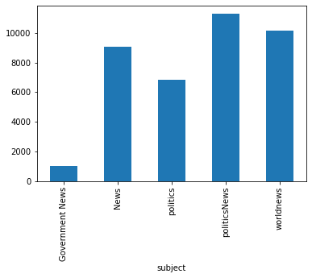

```python
print(data.groupby(['subject'])['text'].count())
data.groupby(['subject'])['text'].count().plot(kind='bar')
plt.show()
```

How many fake and true articles per subject

```
subject          target
Government News  0          1030
News             0          9050
politics         0          6839
politicsNews     1         11272
worldnews        1         10145
Name: text, dtype: int64
```

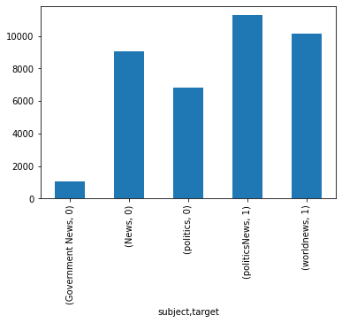

```python
print(data.groupby(['subject', 'target'])['text'].count())
data.groupby(['subject', 'target'])['text'].count().plot(kind='bar')
plt.show()
```

How many true and fake articles

```
target
0    16920
1    21417
Name: text, dtype: int64
```

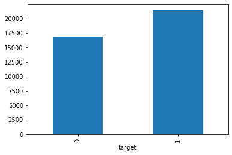

```python
print(data.groupby(['target'])['text'].count())
data.groupby(['target'])['text'].count().plot(kind='bar')
plt.show()
```

Wordcloud for fake articles

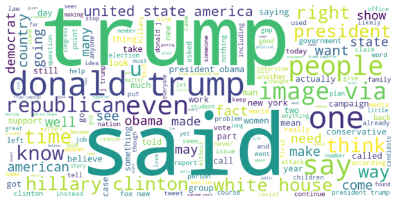

```python
from wordcloud import WordCloud
fake_news = data[data['target'] == 0]
fake_news_text = ' '.join(fake_news['text'])
wordcloud = WordCloud(background_color='white', width=1000, height=500).generate(fake_news_text)
plt.figure(figsize=(10,8))
plt.imshow(wordcloud)
plt.axis('off')
plt.show()
```

Wordcloud for true articles

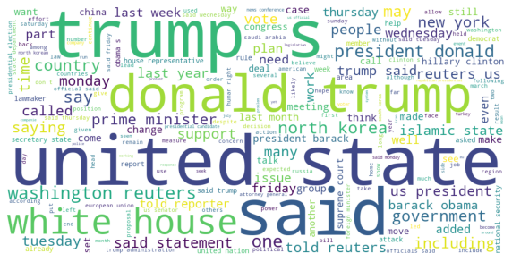

```python
true_news = data[data['target'] == 1]
true_news_text = ' '.join(true_news['text'])
wordcloud = WordCloud(background_color='white', width=1000, height=500).generate(true_news_text)
plt.figure(figsize=(10,8))
plt.imshow(wordcloud)
plt.axis('off')
plt.show()
```

Most frequent words counter

```python
# Code adapted from https://www.kaggle.com/rodolfoluna/fake-news-detector

from nltk import tokenize

token_space = tokenize.WhitespaceTokenizer()

def counter(text, column_text, quantity):
    all_text = ' '.join(text[column_text])
    token_text = token_space.tokenize(all_text)
    counter_text = nltk.FreqDist(token_text)
    word_frequency = pd.DataFrame({'word': list(counter_text.keys()), 'count': list(counter_text.values())})
    word_frequency = word_frequency.nlargest(quantity, 'count')
    plt.figure(figsize=(10,8))
    ax = sns.barplot(x='word', y='count', data=word_frequency)
    ax.set(ylabel='Count')
    ax.set_xticklabels(ax.get_xticklabels(), rotation=90)
    plt.show()
```

Most frequent words in fake articles

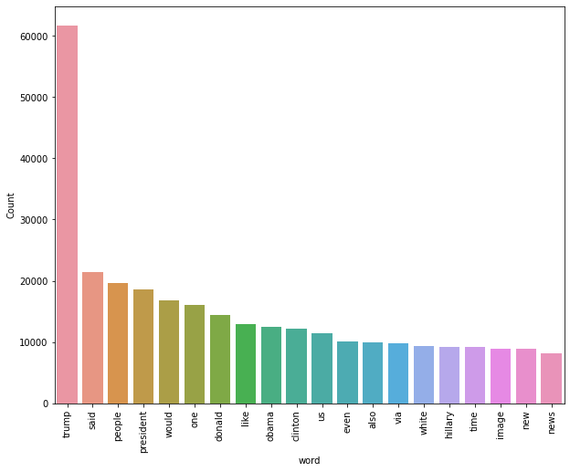

```python
counter(data[data["target"] == 0], "text", 20)
```

Most frequent words in true articles

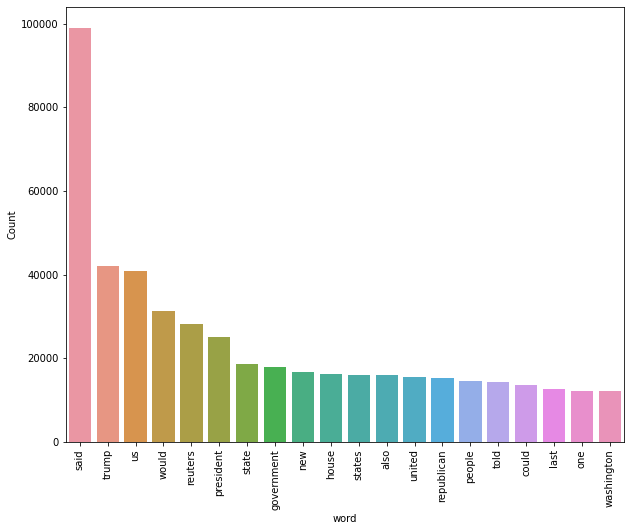

```python
counter(data[data["target"] == 1], "text", 20)
```

Function to plot confusion matrix

```python
# Code from https://scikit-learn.org/stable/auto_examples/model_selection/plot_confusion_matrix.html
from sklearn import metrics
from sklearn.metrics import confusion_matrix
import itertools

def plt_confusion_matrix(cm, classes, normalize=False, title='Confusion matrix', cmap=plt.cm.Blues):
    plt.imshow(cm, interpolation='nearest', cmap=cmap)
    plt.title(title)
    plt.colorbar()
    tick_marks = np.arange(len(classes))
    plt.xticks(tick_marks, classes, rotation=45)
    plt.yticks(tick_marks, classes)

    if normalize:
        cm = cm.astype('float') / cm.sum(axis=1)[:, np.newaxis]

    thresh = cm.max() / 2.
    for i, j in itertools.product(range(cm.shape[0]), range(cm.shape[1])):
        plt.text(j, i, cm[i, j], horizontalalignment="center", color="white" if cm[i, j] > thresh else "black")

    plt.tight_layout()
    plt.ylabel('True label')
    plt.xlabel('Predicted label')
    plt.show()
```

```python
from sklearn.model_selection import train_test_split
```

Split the data into training and testing sets

```python
X_train, X_test, y_train, y_test = train_test_split(data['text'], data['target'], test_size=0.2)
```

# Logistic Regression

```python
# importing libraries
from sklearn.linear_model import LogisticRegression
from sklearn.feature_extraction.text import CountVectorizer
from sklearn.feature_extraction.text import TfidfTransformer
from sklearn import feature_extraction, linear_model, model_selection, preprocessing
from sklearn.metrics import precision_score, recall_score, f1_score, accuracy_score

from sklearn.pipeline import Pipeline
```

Creating dictionary for models.

```python
dct_precision = dict()
dct_recall = dict()
dct_f1 = dict()
```

Vectorizing and applying the TF-IDF

```python
pipe = Pipeline([('vect', CountVectorizer()),
                 ('tfidf', TfidfTransformer()),
                 ('clf', LogisticRegression())])
```

Fitting the model

```python
ml_model_LG = pipe.fit(X_train, y_train)
```

Precision score for Logistic Regression

```python
prediction_LG = ml_model_LG.predict(X_test)
print("Precision: {}%".format(round(precision_score(y_test, prediction_LG)*100,2)))
dct_precision['Logistic Regression'] = round(precision_score(y_test, prediction_LG)*100,2)
```

```
Precision: 98.39%
```

Recall score for Logistic Regression

```python
print("Recall: {}%".format(round(recall_score(y_test, prediction_LG)*100,2)))
dct_recall['Logistic Regression'] = round(recall_score(y_test, prediction_LG)*100,2)
```

```
Recall: 99.33%
```

f1 score for Logistic Regression

```python
print("F1 score: {}%".format(round(f1_score(y_test, prediction_LG)*100,2)))
dct_f1['Logistic Regression'] = round(f1_score(y_test, prediction_LG)*100,2)
```

```
F1 score: 98.86%
```

Confusion matrix for Logistic Regression

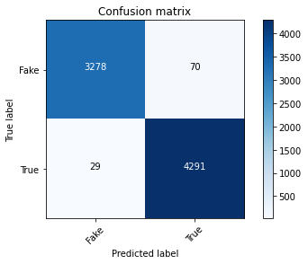

```python
confusion_matrix_LG = confusion_matrix(y_test, prediction_LG)
plt_confusion_matrix(confusion_matrix_LG, ['Fake', 'True'])
```

```python
from sklearn.model_selection import learning_curve
```

Plot learning curve

```python
def plot_learning_curve(estimator, title, X, y, ylim=None, cv=None):
    plt.figure()
    plt.title(title)
    if ylim is not None:
        plt.ylim(*ylim)
    plt.xlabel("Training examples")
    plt.ylabel("Score")
    train_sizes, train_scores, test_scores = learning_curve(estimator, X, y, cv=cv, n_jobs=1, train_sizes=np.linspace(.1, 1.0, 5))
    train_scores_mean = np.mean(train_scores, axis=1)
    train_scores_std = np.std(train_scores, axis=1)
    test_scores_mean = np.mean(test_scores, axis=1)
    test_scores_std = np.std(test_scores, axis=1)
    plt.grid()
    plt.fill_between(train_sizes, train_scores_mean - train_scores_std, train_scores_mean + train_scores_std, alpha=0.1, color="r")
    plt.fill_between(train_sizes, test_scores_mean - test_scores_std, test_scores_mean + test_scores_std, alpha=0.1, color="g")
    plt.plot(train_sizes, train_scores_mean, 'o-', color="r", label="Training score")
    plt.plot(train_sizes, test_scores_mean, 'o-', color="g", label="Cross-validation score")
    plt.legend(loc="best")
    return plt
```

Plot learning curve for Logistic Regression

```
<module 'matplotlib.pyplot' from 'c:\\Python310\\lib\\site-packages\\matplotlib\\pyplot.py'>
```

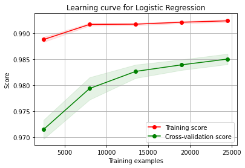

```python
plot_learning_curve(pipe, "Learning curve for Logistic Regression", X_train, y_train, cv=5)
```

# Decision Tree

```python
from sklearn.tree import DecisionTreeClassifier
```

Vectorizing and applying the TF-IDF

```python
pipe = Pipeline([
                ('vect', CountVectorizer()),
                ('tfidf', TfidfTransformer()),
                ('clf', DecisionTreeClassifier(criterion='entropy', max_depth=20,
                splitter='best', random_state=None))])
```

fitting the model for Decision Tree

```python
ml_model_DTC = pipe.fit(X_train, y_train)
```

Precision score for Decision Tree

```python
prediction_DTC = ml_model_DTC.predict(X_test)
print("Precision: {}%".format(round(precision_score(y_test, prediction_DTC)*100,2)))
dct_precision['Decision Tree'] = round(precision_score(y_test, prediction_DTC)*100,2)
```

```
Precision: 99.65%
```

Recall for Decision Tree

```python
print("Recall: {}%".format(round(recall_score(y_test, prediction_DTC)*100,2)))
dct_recall['Decision Tree'] = round(recall_score(y_test, prediction_DTC)*100,2)
```

```
Recall: 99.75%
```

f1 score for Decision Tree

```python
print("F1 score: {}%".format(round(f1_score(y_test, prediction_DTC)*100,2)))
dct_f1['Decision Tree'] = round(f1_score(y_test, prediction_DTC)*100,2)
```

```
F1 score: 99.7%
```

Confusion matrix for Decision Tree

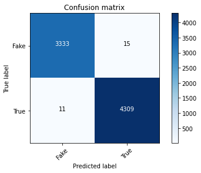

```python
confusion_matrix_DTC = confusion_matrix(y_test, prediction_DTC)
plt_confusion_matrix(confusion_matrix_DTC, ['Fake', 'True'])
```

Learning curve for Decision Tree

```
<module 'matplotlib.pyplot' from 'c:\\Python310\\lib\\site-packages\\matplotlib\\pyplot.py'>
```

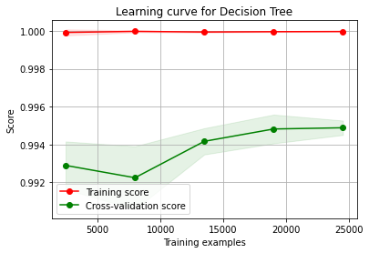

```python
plot_learning_curve(pipe, "Learning curve for Decision Tree", X_train, y_train, cv=5)
```

# Random Forest

```python
from sklearn.ensemble import RandomForestClassifier

pipe = Pipeline([('vect', CountVectorizer()),
                 ('tfidf', TfidfTransformer()),
                 ('model', RandomForestClassifier(n_estimators=50, criterion="entropy"))])
```

Fitting the model for Random forest

```python
ml_model_RF = pipe.fit(X_train, y_train)
```

Precision score for Random Forest Classifier

```python
prediction_RF = ml_model_RF.predict(X_test)
print("Precision: {}%".format(round(precision_score(y_test, prediction_RF)*100,2)))
dct_precision['Random Forest'] = round(precision_score(y_test, prediction_RF)*100,2)
```

```
Precision: 97.24%
```

Recall for Random Forest Classifier

```python
print("Recall: {}%".format(round(recall_score(y_test, prediction_RF)*100,2)))
dct_recall['Random Forest'] = round(recall_score(y_test, prediction_RF)*100,2)
```

```
Recall: 99.44%
```

f1 score for random forest

```python
print("F1 score: {}%".format(round(f1_score(y_test, prediction_RF)*100,2)))
dct_f1['Random Forest'] = round(f1_score(y_test, prediction_RF)*100,2)
```

```
F1 score: 98.33%
```

Confusion matrix for Random forest

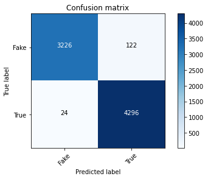

```python
confusion_matrix_RF = confusion_matrix(y_test, prediction_RF)
plt_confusion_matrix(confusion_matrix_RF, ['Fake', 'True'])
```

Learning curve for Random forest

```
<module 'matplotlib.pyplot' from 'c:\\Python310\\lib\\site-packages\\matplotlib\\pyplot.py'>
```

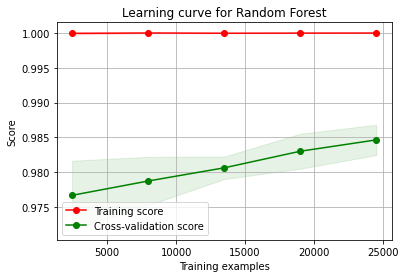

```python
plot_learning_curve(pipe, "Learning curve for Random Forest", X_train, y_train, cv=5)
```

Compare scores of all the models

```python
print("Precision scores:")
print(dct_precision)
print("Recall scores:")
print(dct_recall)
print("F1 scores:")
print(dct_f1)
```

```
Precision scores:
{'Logistic Regression': 98.39, 'Decision Tree': 99.65, 'Random Forest': 97.24}
Recall scores:
{'Logistic Regression': 99.33, 'Decision Tree': 99.75, 'Random Forest': 99.44}
F1 scores:
{'Logistic Regression': 98.86, 'Decision Tree': 99.7, 'Random Forest': 98.33}
```

Compare perecision scores of all the models in bar chart

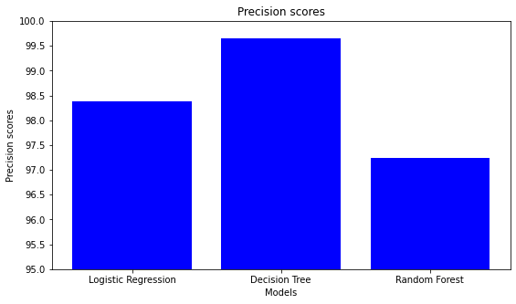

```python
plt.figure(figsize=(9,5))
plt.bar(dct_precision.keys(), dct_precision.values(), color='blue')
plt.title("Precision scores")
plt.xlabel("Models")
plt.ylabel("Precision scores")
plt.ylim(95,100)
plt.yticks(np.arange(95,100.1,0.5))
plt.show()
```

Compare recall scores of all the models in bar chart

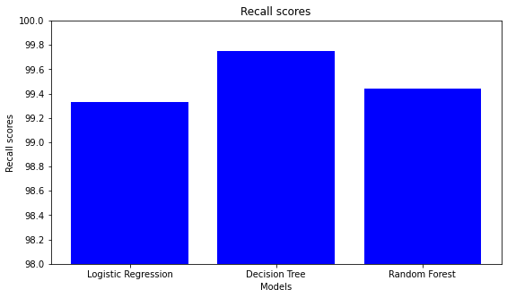

```python
plt.figure(figsize=(9,5))
plt.bar(dct_recall.keys(), dct_recall.values(), color='blue')
plt.title("Recall scores")
plt.xlabel("Models")
plt.ylabel("Recall scores")
plt.ylim(98,100)
plt.yticks(np.arange(98,100.1,0.2))
plt.show()
```

Compare f1 scores of all the models in bar chart

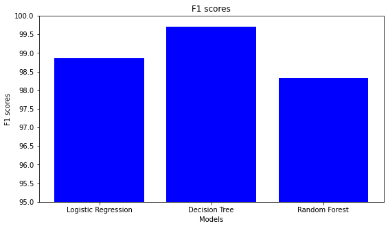

```python
plt.figure(figsize=(9,5))
plt.bar(dct_f1.keys(), dct_f1.values(), color='blue')
plt.title("F1 scores")
plt.xlabel("Models")
plt.ylabel("F1 scores")
plt.ylim(95,100)
plt.yticks(np.arange(95,100.1,0.5))
plt.show()
```

Compare all models in line chart

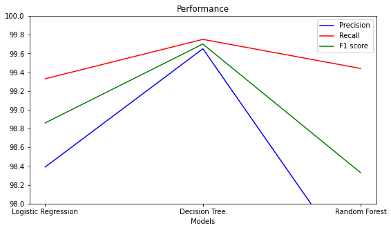

```python
plt.figure(figsize=(9,5))
plt.plot(dct_precision.keys(), dct_precision.values(), color='blue')
plt.plot(dct_recall.keys(), dct_recall.values(), color='red')
plt.plot(dct_f1.keys(), dct_f1.values(), color='green')
plt.title("Performance")

plt.legend(['Precision', 'Recall', 'F1 score'])
plt.xlabel("Models")
plt.ylim(98,100)
plt.yticks(np.arange(98,100.1,0.2))
plt.show()
```